# Distribuição de Probabilidades

Gabriela, Matheus, Vitor

06/05/2020

## 5.2 Poisson

É comum encontrarmos problemas em que o número de ocorrência de determinado evento é obtido a partir da distribuição Poisson com uma taxa λ. Neste tópico apresentaremos funções bem similares às que vimos no tópico referente à distribuição binomial, são elas: ppois, dpois e qpois.

A probabilidade de eventos envolvendo a distribuição de Poisson podem ser calculadas através da seguinte função de probabilidade:

$$P(X=k) = \frac{e^{-λ}λ^k}{x!}$$

### 5.2.1 Função dpois

Assim como em *dbinom*, a função *dpois* nos retorna a probabilidade associada a um valor de X. A diferença entre *dbinom* e *dpois* são os parâmetros que passamos para a função, devido à característica de cada modelo. No caso da binomial, devemos informar o tamanho do experimento e a probabilidade de sucesso, na Poisson precisamos informar apenas o valor do parâmetro λ.

**Exemplo**

Suponha que um determinado em uma fábrica de laticínios, na etapa de embalagens podem ocorrer falhas, de acordo com uma variável aleatória X que segue uma distribuição de Poisson de parâmetro λ = 3.

Estamos interessados na probabilidade de 5 caixas de leite apresentarem alguma deformação.

Usando a funçao *dpois*, calculamos o valor de P(X=5)com λ =3.

```r
dpois(x = 5, lambda = 3)
```

```
## [1] 0.1008188
```

A função *ppois* retorna o valor da prababilidade acumulada avaliada em um X qualquer. No nosso exemplo deﬁnimos X = 5 e λ = 3.

P(X ≤ 5):

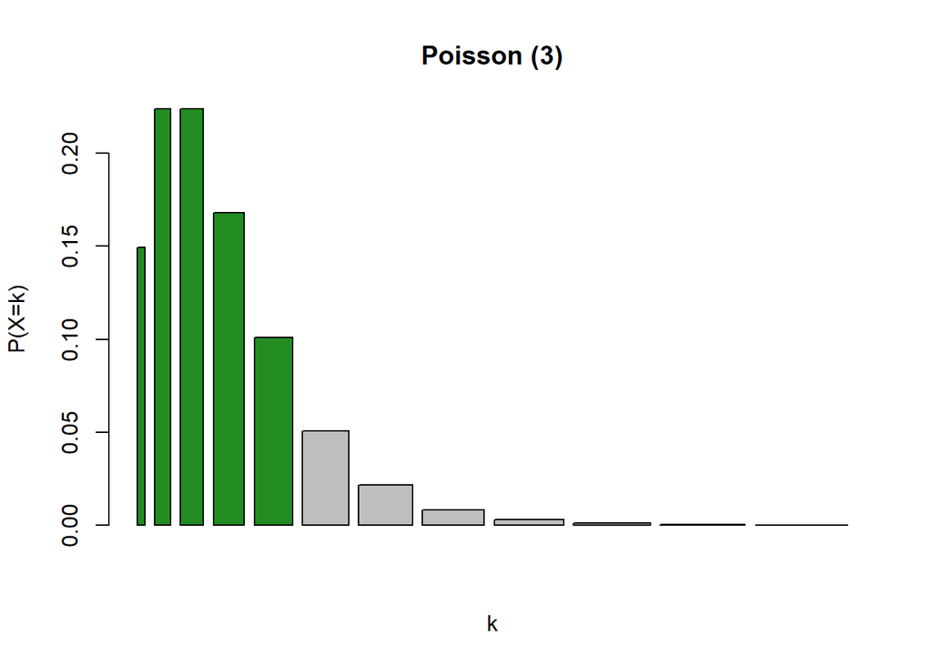

No nosso exemplo sobre a etapa de embalagens, se estivéssemos interessados na probabilidade de 5 caixas de leite, ou menos,apresentar defeito, bastaria utilizar o comando *ppois* da seguinte maneira:

```r
ppois(q = 5, lambda = 3)
```

```
## [1] 0.9160821
```

Assim como ﬁzemos com a função *pbinom*, podemos conferir o resultado obtido com a função *ppois* comparando com o resultado obtido com a soma de probabilidades utilizando a função *dpois*. Veja:

```r
dpois(x = 5, lambda = 3)+
dpois(x = 4, lambda = 3)+
dpois(x = 3, lambda = 3)+
dpois(x = 2, lambda = 3)+
dpois(x = 1, lambda = 3)+
dpois(x = 0, lambda = 3)
```

```
## [1] 0.9160821
```

P(X > 5) :

```r
ppois(q = 5, lambda = 3, lower.tail = FALSE)
```

```
## [1] 0.08391794
```

A utilização da do parâmetro lower.tail foi devidamente discutida no tópico da função pbinom.

### 5.2.3 Funçao qpois

```r
qpois(p =0.95, lambda = 3)
```

```
## [1] 6
```